# Statistical inference, Course Project

Assignment text in *italic*.

*Illustrate via simulation and associated explanatory text the properties of the distribution of the mean of 40 exponential(0.2)s. You should*

## Question 1

*1. Show where the distribution is centered at and compare it to the theoretical center of the distribution.*

Show the distribution of 1000 means of 40 exponential(0.2)s and calculate the mean.

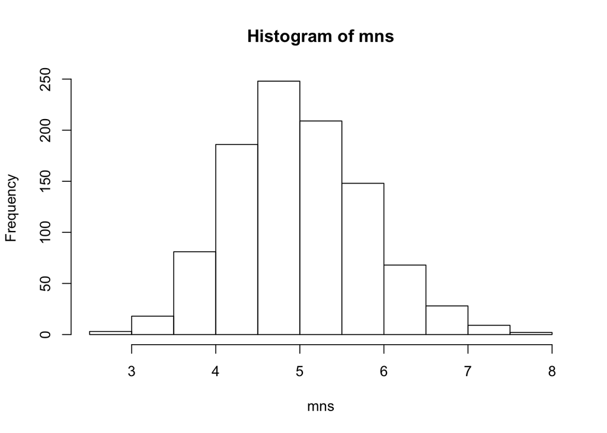

```r
# Reset the means variable
mns <- NULL
# Set the number of simulations
sim <- 1000
# Simulate 1000 means of 40 exponential(0.2)s and accumulate the mean into mns
for (i in 1 : sim) mns = c(mns, mean(rexp(40, 0.2)))
# Draw a histogram of the means
hist(mns)
```

```r
# Print the mean of the means, which is where the distribution is centered
mean(mns)
```

```
## [1] 4.979121
```

The distribution is centered around 5, which is also the theoretical center of the distribution 1/lambda = 1/0.2 = 5.

## Question 2

*2. Show how variable it is and compare it to the theoretical variance of the distribution.*

```r
# Reset the sds variable
sds <- NULL
# Set the number of simulations
sim <- 1000
# Simulate 1000 standard deviations of 40 exponential(0.2)s and accumulate the mean into sds
for (i in 1 : sim) sds = c(sds, sd(rexp(40, 0.2)))

# Calculate the standard error of the mean
mean(sds)/sqrt(40)
```

```
## [1] 0.7743809
```

```r
# Calculate the theoretical standard error of the mean
(1/0.2)/sqrt(40)
```

```
## [1] 0.7905694
```

The standard error of the mean is roughly 0.78, which is in line with the theoretical (1/lambda)/sqrt(n) = 0.79

*3. Show that the distribution is approximately normal.*

We continue with the originally simulated distribution of means.  
The Central Limit Theorem states “given a population with a finite mean μ and a finite non-zero variance σ2, the sampling distribution of the mean approaches a normal distribution with a mean of μ and a variance of σ2/N as N increases.”  
We test to what extent the distribution of means is normal with the Shapiro-Wilk test of normality.

```r
shapiro.test(mns)
```

```
##
##  Shapiro-Wilk normality test
##
## data:  mns
## W = 0.9935, p-value = 0.0002399
```